# ICU Admissions Term Project, eH705

# 6 Distribution

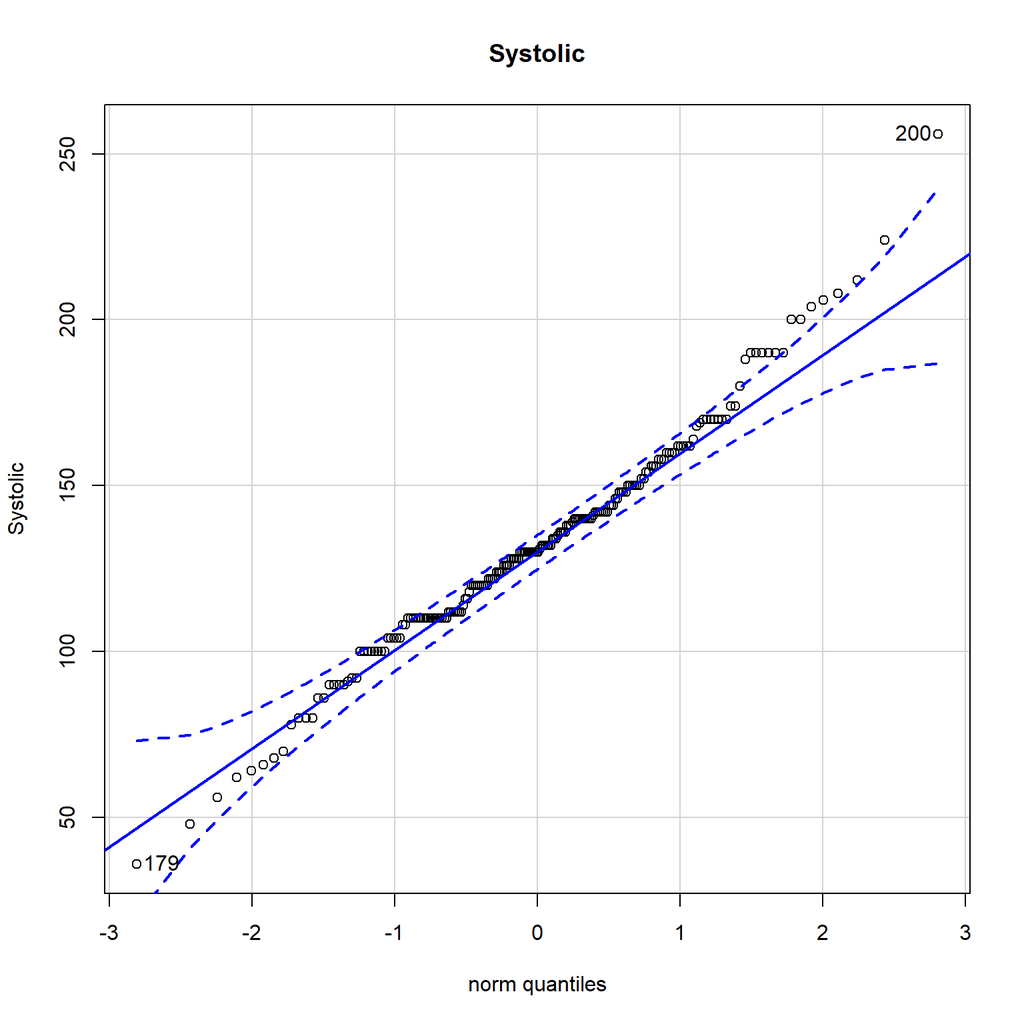

```
[1] 200 179
```

```r
> with(ICU, qqPlot(Systolic, dist="norm", id=list(method="y", n=2,
+   labels=rownames(ICU)), main="Systolic"))
```

```r
> normalityTest(~Systolic, test="shapiro.test", data=ICU)
```

```
    Shapiro-Wilk normality test

data:  Systolic
W = 0.98369, p-value = 0.0204
```

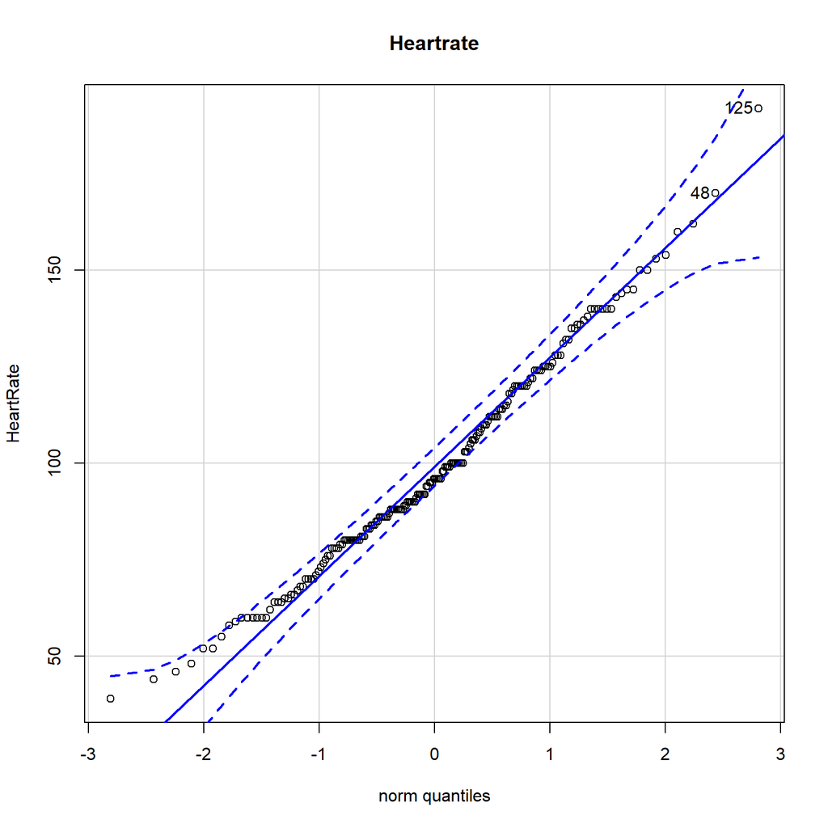

```
[1] 125  48
```

```r
> with(ICU, qqPlot(HeartRate, dist="norm", id=list(method="y", n=2,
+   labels=rownames(ICU)), main="Heartrate"))
```

```r
> normalityTest(~HeartRate, test="shapiro.test", data=ICU)
```

```
    Shapiro-Wilk normality test

data:  HeartRate
W = 0.98598, p-value = 0.04478
```

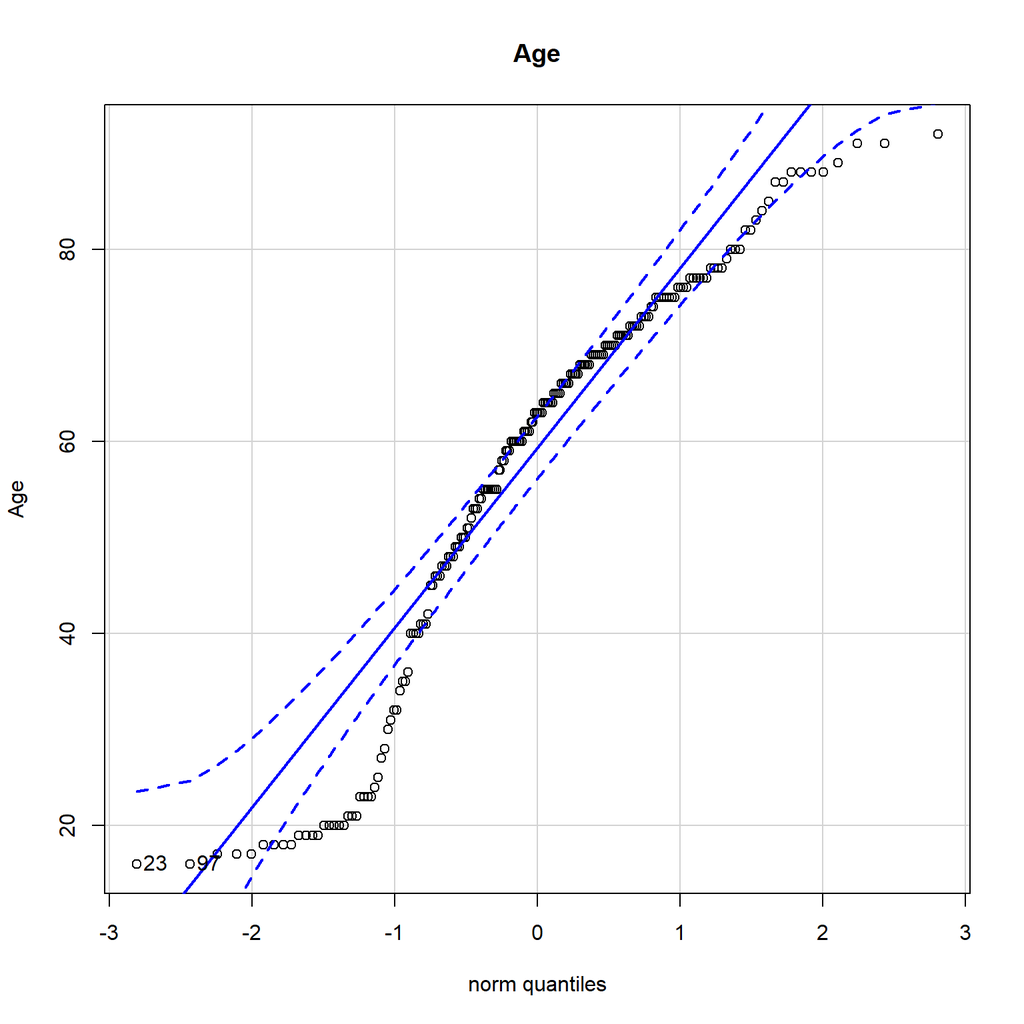

```
[1] 23 97
```

```r
> with(ICU, qqPlot(Age, dist="norm", id=list(method="y", n=2,
+   labels=rownames(ICU)), main="Age"))
```

```r
> normalityTest(~Age, test="shapiro.test", data=ICU)
```

```
    Shapiro-Wilk normality test

data:  Age
W = 0.92836, p-value = 2.507e-08
```

# 7 Differences in Means

## 7.1 Summary Statistics

```r
> numSummary(ICU[,c("Age", "Systolic", "HeartRate"), drop=FALSE], groups=ICU$Status, statistics=c("mean", "sd", "se(mean)"),quantiles=c(0,.25, .5, .75,1))
```

```
Variable: Age
        mean       sd se(mean)   n
Lived 55.650 20.42818 1.614990 160
Died  65.125 16.64900 2.632438  40

Variable: Systolic
          mean       sd se(mean)   n
Lived 135.6438 29.80151 2.356016 160
Died  118.8250 41.08084 6.495451  40

Variable: HeartRate
         mean       sd se(mean)   n
Lived  98.500 26.97868 2.132852 160
Died  100.625 26.49304 4.188918  40
```

```r
> library(psych)
> describeBy(ICU, ICU$Status)
```

```
 Descriptive statistics by group
group: Lived
               vars   n   mean     sd median trimmed    mad min max range
ID                1 160 457.04 276.35  438.5  454.25 346.19   8 929   921
Status*           2 160   1.00   0.00    1.0    1.00   0.00   1   1     0
Age               3 160  55.65  20.43   61.0   56.86  19.27  16  91    75
Sex*              4 160   1.38   0.49    1.0    1.34   0.00   1   2     1
Race*             5 160   1.19   0.50    1.0    1.05   0.00   1   3     2
Service*          6 160   1.58   0.49    2.0    1.60   0.00   1   2     1
Cancer*           7 160   1.10   0.30    1.0    1.00   0.00   1   2     1
Renal*            8 160   1.07   0.25    1.0    1.00   0.00   1   2     1
Infection*        9 160   1.38   0.49    1.0    1.34   0.00   1   2     1
CPR*             10 160   1.04   0.19    1.0    1.00   0.00   1   2     1
Systolic         11 160 135.64  29.80  132.0  133.97  29.65  48 224   176
HeartRate        12 160  98.50  26.98   95.0   97.48  25.20  39 192   153
Previous*        13 160   1.14   0.35    1.0    1.05   0.00   1   2     1
Type*            14 160   1.68   0.47    2.0    1.73   0.00   1   2     1
Fracture*        15 160   1.07   0.26    1.0    1.00   0.00   1   2     1
PO2*             16 160   1.07   0.25    1.0    1.00   0.00   1   2     1
PH*              17 160   1.06   0.23    1.0    1.00   0.00   1   2     1
PCO2*            18 160   1.10   0.30    1.0    1.00   0.00   1   2     1
Bicarbonate*     19 160   1.06   0.24    1.0    1.00   0.00   1   2     1
Creatinine*      20 160   1.03   0.17    1.0    1.00   0.00   1   2     1
Consciousness*   21 160   1.02   0.22    1.0    1.00   0.00   1   3     2
                skew kurtosis    se
ID              0.07    -1.25 21.85
Status*          NaN      NaN  0.00
Age            -0.55    -0.82  1.61
Sex*            0.51    -1.75  0.04
Race*           2.65     5.98  0.04
Service*       -0.33    -1.91  0.04
Cancer*         2.64     5.01  0.02
Renal*          3.38     9.46  0.02
Infection*      0.51    -1.75  0.04
CPR*            4.82    21.40  0.02
Systolic        0.42     0.34  2.36
HeartRate       0.44     0.17  2.13
Previous*       2.01     2.06  0.03
Type*          -0.77    -1.41  0.04
Fracture*       3.20     8.27  0.02
```

[output cut: 37 more lines]

```
Cancer*         2.57     4.71  0.05
Renal*          1.44     0.09  0.06
Infection*     -0.39    -1.89  0.08
CPR*            1.65     0.73  0.06
Systolic        0.60     1.40  6.50
HeartRate       0.28    -0.75  4.19
Previous*       1.65     0.73  0.06
Type*          -3.98    14.16  0.03
Fracture*       3.11     7.85  0.04
PO2*            2.18     2.84  0.05
PH*             2.57     4.71  0.05
PCO2*           2.57     4.71  0.05
Bicarbonate*    2.18     2.84  0.05
Creatinine*     2.18     2.84  0.05
Consciousness*  1.03    -0.74  0.13
```

## 7.2 Age by Status

**Ho:** the variances for Lived and Died are equal  
**Ha:** the variances are different

**Ho:** the means are equal  
**Ha:** the means are different

The following is the comparison of variances between the two Status groups for Age.

```r
> with(ICU, tapply(Age, Status, var, na.rm=TRUE))
```

```
   Lived     Died
417.3107 277.1891
```

The following code produces the result of the LeveneTest for testing homogeneity of variances.

```r
> leveneTest(Age ~ Status, data=ICU, center="median")
```

```
Levene's Test for Homogeneity of Variance (center = "median")
       Df F value  Pr(>F)
group   1   3.127 0.07855 .
      198
---
Signif. codes:  0 '***' 0.001 '**' 0.01 '*' 0.05 '.' 0.1 ' ' 1
```

Since the p value = 0.07855 for testing the homogeneity of variances is greater than 0.05, we retain the null hypothesis with a 5% risk of a type 1 error and conclude that the variances for Lived and Died are equal. As such, the Student t-test is used to analyze whether there was a significant difference in means.

```r
> t.test(Age~Status, alternative='two.sided', conf.level=.95, var.equal=TRUE, data=ICU)
```

```
    Two Sample t-test

data:  Age by Status
t = -2.7151, df = 198, p-value = 0.007211
alternative hypothesis: true difference in means is not equal to 0
95 percent confidence interval:
 -16.35688  -2.59312
sample estimates:
mean in group Lived  mean in group Died
             55.650              65.125
```

```r
> qt(c(0.025), df=314, lower.tail=TRUE)
```

```
[1] -1.967548
```

## 7.3 HeartRate by Status

**Ho:** the variances for Lived and Died are equal  
**Ha:** the variances are different

**Ho:** the means are equal  
**Ha:** the means are different

The following is the comparison of variances between the two Status groups for HeartRate.

```r
> with(ICU, tapply(HeartRate, Status, var, na.rm=TRUE))
```

```
   Lived     Died
727.8491 701.8814
```

The following code produces the result of the LeveneTest for testing homogeneity of variances.

```r
> leveneTest(HeartRate ~ Status, data=ICU, center="median")
```

```
Levene's Test for Homogeneity of Variance (center = "median")
       Df F value Pr(>F)
group   1   0.008  0.929
      198
```

Since the p-value = 0.929 for testing the homogeneity of variances is greater than 0.05, we retain the null hypothesis with a 5% risk of a type 1 error and conclude that the variances for Lived and Died are equal. As such, the Student t-test is used to analyze whether there was a significant difference in means.

```r
> t.test(HeartRate~Status, alternative='two.sided', conf.level=.95, var.equal=TRUE, data=ICU)
```

```
    Two Sample t-test

data:  HeartRate by Status
t = -0.44714, df = 198, p-value = 0.6553
alternative hypothesis: true difference in means is not equal to 0
95 percent confidence interval:
 -11.496845   7.246845
sample estimates:
mean in group Lived  mean in group Died
             98.500             100.625
```

```r
> qt(c(0.025), df=314, lower.tail=TRUE)
```

```
[1] -1.967548
```

As the p-value = 0.6553, 0 is within the confidence intervals of -11.496845 to 7.246845 and t = -0.44714 is greater than -1.967548, we retain the null hypothesis at a 5% risk level of a type 1 error and conclude that the means for HeartRate are the same among those that lived and those that died.

## 7.4 Systolic by Status

**Ho:** the variances for Lived and Died are equal  
**Ha:** the variances are different

**Ho:** the means are equal  
**Ha:** the means are different

The following is the comparison of variances between the two Status groups for Systolic.

```r
> with(ICU, tapply(Systolic, Status, var, na.rm=TRUE))
```

```
    Lived      Died
 888.1301 1687.6353
```

The following code produces the result of the LeveneTest for testing homogeneity of variances.

```r
> leveneTest(Systolic ~ Status, data=ICU, center="median")
```

```
Levene's Test for Homogeneity of Variance (center = "median")
       Df F value  Pr(>F)
group   1  4.1872 0.04205 *
      198
---
Signif. codes:  0 '***' 0.001 '**' 0.01 '*' 0.05 '.' 0.1 ' ' 1
```

Since the p-value = 0.04205 for testing the homogeneity of variances is less than 0.05, we reject the null hypothesis with a 5% risk of a type 1 error and conclude that the variances for Lived and Died are not equal. As such, the Welch two Sample t-test is used to analyze whether there was a significant difference in means.

```r
> t.test(Systolic~Status, alternative="two.sided", conf.level=.95, var.equal=FALSE, data=ICU)
```

```
    Welch Two Sample t-test

data:  Systolic by Status
t = 2.4341, df = 49.726, p-value = 0.01856
alternative hypothesis: true difference in means is not equal to 0
95 percent confidence interval:
  2.938642 30.698858
sample estimates:
mean in group Lived  mean in group Died
           135.6438            118.8250
```

```r
> qt(c(0.025), df=314, lower.tail=TRUE)
```

```
[1] -1.967548
```

As the p-value = 0.01856, 0 is not within the confidence intervals of 2.938642 to 30.698858 and t = 2.4341 is greater than 1.9675, we reject the null hypothesis at a 5% risk level of a type 1 error and conclude that the means for systolic blood pressure are not the same among those that lived and those that died.

## 7.5 Age by Sex

**Ho:** the variances for Lived and Died are equal  
**Ha:** the variances are different

**Ho:** the means are equal  
**Ha:** the means are different

The following is the comparison of variances between the two Sex groups for Age.

```r
> with(ICU, tapply(Age, Sex, var, na.rm=TRUE))
```

```
    Male   Female
378.4780 436.5867
```

The following code produces the result of the LeveneTest for testing homogeneity of variances.

```r
> leveneTest(Age ~ Sex, data=ICU, center="median")
```

```
Levene's Test for Homogeneity of Variance (center = "median")
       Df F value Pr(>F)
group   1  0.1154 0.7344
      198
```

Since the p-value = 0.7344 for testing the homogeneity of variances is greater than 0.05, we retain the null hypothesis with a 5% risk of a type 1 error and conclude that the variances for Lived and Died are equal. As such, the Student t-test is used to analyze whether there was a significant difference in means.

```r
> t.test(Age~Sex, alternative='two.sided', conf.level=.95, var.equal=TRUE, data=ICU)
```

```
    Two Sample t-test

data:  Age by Sex
t = -1.3582, df = 198, p-value = 0.1759
alternative hypothesis: true difference in means is not equal to 0
95 percent confidence interval:
 -9.708824  1.789469
sample estimates:
  mean in group Male mean in group Female
            56.04032             60.00000
```

```r
> qt(c(0.025), df=314, lower.tail=TRUE)
```

```
[1] -1.967548
```

# 8 Sajiya

# 9 Difference in proportions

We will conduct z-tests between two categorical variables where the dependent variable is Vital status and the independent variable is binary.

Vital status by Service

Ho: there is no difference between the proportion of patients that died in the medical versus surgical group, risk = 0.05 Ha: there is a difference between the proportion of patients that died in the medical versus surgical group

```r
> pacman::p_load(sjPlot)
> sjt.xtab(ICU$Status, ICU$Service, show.col.prc = TRUE)
```

| Status | Service |  | Total |  |
| --- | --- | --- | --- | --- |
|  | Medical | Surgical |  |  |
| Lived | 67 72 % | 93 86.9 % |  | 160 80 % |
| Died | 26 28 % | 14 13.1 % | 40 20 % |  |
| Total | 93 100 % | 107 100 % | 200 100 % |  |

```r
> x1<-26; x2<-14; n1<-93; n2<-107
> p1<-x1/n1; p2<-x2/n2
> p<-(x1+x2)/(n1+n2)
> varp<-p*(1-p)*(1/n1 + 1/n2)
> stdp<-sqrt(varp)
> zp<-(p1 - p2)/stdp
> zp
```

```
[1] 2.622729
```

```r
> 1-pnorm(zp)
```

```
[1] 0.004361436
```

When conducting a two-tail z-test with a 5% level of risk of a type 1 error, the critical values are -1.96 and +1.96. The z-value of 2.622729 does not fall within this confidence interval, thus we reject the null hypothesis that there is no difference between the proportion of patients dying in the ICU from medical procedures versus surgical procedures.

Further, since the p-value of 0.004361436 is less than 0.05, we, again, reject the null hypothesis that the proportions of the two groups are equal.

Lastly, we can see from the table that more of those that died were there for a medical service and more of those that lived were there for a surgical service.

Vital status by Cancer

Ho: there is no difference between the proportions of patients that died in the cancer versus non-cancer group, risk = 0.05 Ha: there is a difference between the proportions of patients that died in the cancer versus non-cancer group

```r
> pacman::p_load(sjPlot)
> sjt.xtab(ICU$Status, ICU$Cancer, show.col.prc = TRUE)
```

| Status | Cancer |  | Total |  |
| --- | --- | --- | --- | --- |
|  | No | Yes |  |  |
| Lived | 144 80 % | 16 80 % |  | 160 80 % |
| Died | 36 20 % | 4 20 % | 40 20 % |  |
| Total | 180 100 % | 20 100 % | 200 100 % |  |

```r
> x1<-36; x2<-4; n1<-180; n2<-20
> p1<-x1/n1; p2<-x2/n2
> p<-(x1+x2)/(n1+n2)
> varp<-p*(1-p)*(1/n1 + 1/n2)
> stdp<-sqrt(varp)
> zp<-(p1 - p2)/stdp
> zp
```

```
[1] 0
```

```r
> 1-pnorm(zp)
```

```
[1] 0.5
```

When conducting a two-tail z-test with a 5% level of risk of a type 1 error, the critical values are -1.96 and +1.96. The z-value of 0 falls within this confidence interval, thus we fail to reject the null hypothesis that there is no difference between the proportions of patients that died with versus without cancer as part of the present problem.

Further, since the p-value of 0.5 is greater than 0.05, we, again, fail to reject the null hypothesis that the proportions of the Cancer versus non-cancer patients that died are equal.

Thus, there are equal proportions of those who died with cancer as part of the present problem and without, as well as equal proportions of those who lived with cancer as part of the present problem and without.

Vital status by Previous

Ho: there is no difference between the proportion of patients that died with versus without previous admission to an ICU within 6 months, risk = 0.05 Ha: there is a difference between the proportion of patients that died with versus without previous admission to an ICU within 6 months

```r
> pacman::p_load(sjPlot)
> sjt.xtab(ICU$Status, ICU$Previous, show.col.prc = TRUE)
```

| Status | Previous |  | Total |  |
| --- | --- | --- | --- | --- |
|  | No | Yes |  |  |
| Lived | 137 80.6 % | 23 76.7 % |  | 160 80 % |
| Died | 33 19.4 % | 7 23.3 % | 40 20 % |  |
| Total | 170 100 % | 30 100 % | 200 100 % |  |

```r
> x1<-33; x2<-7; n1<-170; n2<-30
> p1<-x1/n1; p2<-x2/n2
> p<-(x1+x2)/(n1+n2)
> varp<-p*(1-p)*(1/n1 + 1/n2)
> stdp<-sqrt(varp)
> zp<-(p1 - p2)/stdp
> zp
```

```
[1] -0.4950738
```

```r
> 1-pnorm(zp)
```

```
[1] 0.689726
```

When conducting a two-tail z-test with a 5% level of risk of a type 1 error, the critical values are -1.96 and +1.96. The z-value of -0.4950738 falls within this confidence interval, thus we fail to reject the null hypothesis that there is no difference between the proportion of patients that died with versus without previous admission to an ICU within 6 months of the current admission.

Further, since the p-value of 0.689726 is greater than 0.05, we, again, fail to reject the null hypothesis that there is no difference between the proportion of patients that died whether or not they were previously admitted to the ICU within the past 6 months.

Lastly, we see from the table that there was a lower percentage of patients that died with no prior ICU admission than patients that died with prior ICU admission.

Vital status by Type

Ho: there is no difference between the proportion of patients that died in the elective admission group versus the emergency admission group, risk = 0.05 Ha: there is a difference between the proportion of patients that died in the elective admission group versus the emergency admission group

```r
> pacman::p_load(sjPlot)
> sjt.xtab(ICU$Status, ICU$Type, show.col.prc = TRUE)
```

| Status | Type |  | Total |  |
| --- | --- | --- | --- | --- |
|  | Elective | Emergency |  |  |
| Lived | 51 96.2 % | 109 74.1 % |  | 160 80 % |
| Died | 2 3.8 % | 38 25.9 % | 40 20 % |  |
| Total | 53 100 % | 147 100 % | 200 100 % |  |

```r
> x1<-2; x2<-38; n1<-53; n2<-147
> p1<-x1/n1; p2<-x2/n2
> p<-(x1+x2)/(n1+n2)
> varp<-p*(1-p)*(1/n1 + 1/n2)
> stdp<-sqrt(varp)
> zp<-(p1 - p2)/stdp
> zp
```

```
[1] -3.444743
```

```r
> pnorm(zp)
```

```
[1] 0.000285801
```

When conducting a two-tail z-test with a 5% level of risk of a type 1 error, the critical values are -1.96 and +1.96. The z-value of -3.444743 does not fall within this confidence interval, thus we reject the null hypothesis that there is no difference between the proportion of patients that died in the elective admission group versus the emergency admission group.

Further, since the p-value of 0.000285801 is less than 0.05, we, again, reject the null hypothesis that the proportions of the two groups are equal.

We can see from the table that the emergency admission type had a higher proportion of deaths than the elective admission type did.

We will now conduct a prop.test for categorical variables where the independent variable has more than 2 subgroups.

Vital status by Age

Ho: there is no difference between the proportion of patients that died across the 5 age groups, risk = 0.05 Ha: the proportion of patients that died is different in at least one of the 5 age groups

Binning the Age variable with equal-count bins.

```r
> ICU$Age.binned <-
+   with(ICU, binVariable(Age,
+    bins=5, method='proportions',
+   labels=c('Group 1','Group 2','Group 3',
+   'Group 4','Group 5')))
```

```r
> pacman::p_load(sjPlot)
> sjt.xtab(ICU$Status, ICU$Age.binned, show.col.prc = TRUE)
```

| Status | Age.binned |  |  |  |  | Total |  |
| --- | --- | --- | --- | --- | --- | --- | --- |
|  | Group 1 | Group 2 | Group 3 | Group 4 | Group 5 |  |  |
| Lived | 38 92.7 % | 31 79.5 % | 34 79.1 % | 33 75 % | 24 72.7 % |  | 160 80 % |
| Died | 3 7.3 % | 8 20.5 % | 9 20.9 % | 11 25 % | 9 27.3 % | 40 20 % |  |
| Total | 41 100 % | 39 100 % | 43 100 % | 44 100 % | 33 100 % | 200 100 % |  |

```r
> Died  <- c( 3, 8, 9, 11, 9 )
> Total <- c( 41, 39, 43, 44, 33 )
> prop.test(Died, Total)
```

```
    5-sample test for equality of proportions without continuity
    correction

data:  Died out of Total
X-squared = 5.93, df = 4, p-value = 0.2044
alternative hypothesis: two.sided
sample estimates:
    prop 1     prop 2     prop 3     prop 4     prop 5
0.07317073 0.20512821 0.20930233 0.25000000 0.27272727
```

Since the p-value of 0.2044 is greater than 0.05, we fail to reject the null hypothesis that there is no difference between the proportion of patients that died across the 5 age groups. We can see from the sample estimates that the proportions are indeed quite similar between the 5 age groups. However, the number of patients that died in age group 1 (the youngest age group) is much lower than the rest. The greatest proportion of patients that died is in group 5 (the oldest age group). The proportions in groups 2 and 3 are quite similar and slightly higher in group 4. However, overall, most of the groups had similar proportions of patients that died, aside from the youngest age group.

Further, when conducting a chi-square test with a 5% level of risk of a type 1 error and 4 degrees of freedom, the critical value is 9.49. Since the chi-squared value of 5.93 is less than this critical value, we, again, fail to reject the null hypothesis that there is no difference between the proportion of patients that died across the 5 age groups.

Vital status by Systolic Blood Pressure

Ho: there is no difference between the proportion of patients that died across the 6 systolic blood pressure level groups, risk = 0.05 Ha: the proportion of patients that died is different in at least one of the 6 systolic blood pressure level groups

```r
> ICU <-
+   within(ICU, {
+   Systolic.grouped <- Recode(Systolic,
+   '0:80="hypotension"; 80:120="normal"; 120:129="elevated"; 130:139="stage 1 hypertension"; 140:180="stage 2 hypertension"; 180:260="stage 3 hypertension"; ;',
+    as.factor=TRUE)
+ })
```

```r
> pacman::p_load(sjPlot)
> sjt.xtab(ICU$Status, ICU$Systolic.grouped, show.col.prc = TRUE)
```

| Status | Systolic.grouped |  |  |  |  |  | Total |  |
| --- | --- | --- | --- | --- | --- | --- | --- | --- |
|  | elevated | hypotension | normal | stage 1 hypertension | stage 2 hypertension | stage 3 hypertension |  |  |
| Lived | 14 82.4 % | 3 25 % | 52 85.2 % | 24 80 % | 54 83.1 % | 13 86.7 % |  | 160 80 % |
| Died | 3 17.6 % | 9 75 % | 9 14.8 % | 6 20 % | 11 16.9 % | 2 13.3 % | 40 20 % |  |
| Total | 17 100 % | 12 100 % | 61 100 % | 30 100 % | 65 100 % | 15 100 % | 200 100 % |  |

```r
> Died  <- c( 3, 9, 9, 6, 11, 2 )
> Total <- c( 17, 12, 61, 30, 65, 15 )
> prop.test(Died, Total)
```

```
    6-sample test for equality of proportions without continuity
    correction

data:  Died out of Total
X-squared = 24.597, df = 5, p-value = 0.0001667
alternative hypothesis: two.sided
sample estimates:
   prop 1    prop 2    prop 3    prop 4    prop 5    prop 6
0.1764706 0.7500000 0.1475410 0.2000000 0.1692308 0.1333333
```

Vital status by Heart Rate

Ho: there is no difference between the proportion of patients that died across the bradychardia, normal heart rate and elevated heart rate groups, risk = 0.05 Ha: the proportion of patients that died is different in at least one of the 3 heart rate categories

```r
> ICU <-
+   within(ICU, {
+   HeartRate.grouped <- Recode(HeartRate,
+   '0:60="bradycardia"; 60:100="normal"; 100:200="elevated"',
+    as.factor=TRUE)
+ })
```

```r
> pacman::p_load(sjPlot)
> sjt.xtab(ICU$Status, ICU$HeartRate.grouped, show.col.prc = TRUE)
```

| Status | HeartRate.grouped |  |  | Total |  |
| --- | --- | --- | --- | --- | --- |
|  | bradycardia | elevated | normal |  |  |
| Lived | 12 80 % | 64 80 % | 84 80 % |  | 160 80 % |
| Died | 3 20 % | 16 20 % | 21 20 % | 40 20 % |  |
| Total | 15 100 % | 80 100 % | 105 100 % | 200 100 % |  |

```r
> Died  <- c( 3, 16, 21 )
> Total <- c( 15, 80, 105 )
> prop.test(Died, Total)
```

```
    3-sample test for equality of proportions without continuity
    correction

data:  Died out of Total
X-squared = 0, df = 2, p-value = 1
alternative hypothesis: two.sided
sample estimates:
prop 1 prop 2 prop 3
   0.2    0.2    0.2
```

Vital status by Race

Ho: there is no difference between the proportion of patients that died that were White, Black or otherwise, risk = 0.05 Ha: the proportion of patients that died is different in at least one of the race categories

```r
> pacman::p_load(sjPlot)
> sjt.xtab(ICU$Status, ICU$Race, show.col.prc = TRUE)
```

| Status | Race |  |  | Total |  |
| --- | --- | --- | --- | --- | --- |
|  | White | Black | Other |  |  |
| Lived | 138 78.9 % | 14 93.3 % | 8 80 % |  | 160 80 % |
| Died | 37 21.1 % | 1 6.7 % | 2 20 % | 40 20 % |  |
| Total | 175 100 % | 15 100 % | 10 100 % | 200 100 % |  |

```r
> Died  <- c( 37, 1, 2 )
> Total <- c( 175, 15, 10 )
> prop.test(Died, Total)
```

```
    3-sample test for equality of proportions without continuity
    correction

data:  Died out of Total
X-squared = 1.8095, df = 2, p-value = 0.4046
alternative hypothesis: two.sided
sample estimates:
    prop 1     prop 2     prop 3
0.21142857 0.06666667 0.20000000
```

Since the p-value of 0.4046 is greater than 0.05, we fail to reject the null hypothesis that there is no difference between the proportion of patients that died that were White, Black or otherwise.

Further, when conducting a chi-square test with a 5% level of risk of a type 1 error and 2 degrees of freedom, the critical value is 5.99. Since the chi-squared value of 1.8095 is less than this critical value, we, again, fail to reject the null hypothesis that there is no difference between the proportion of patients that died that were White, Black or otherwise.

When looking at the sample estimates and at the table, we see that there was almost no difference between the proportion of White patients that died and the proportion of ‘Other’ patients that died. However, the proportion of Black patients that died was slightly lower than the White and ‘Other’ groups.

Vital status by Consciousness

Ho: there is no difference between the proportion of patients that died across the Conscious, Deep Stupor and Coma groups, risk = 0.05 Ha: the proportion of patients that died is different in at least one of the Conscious, Deep Stupor and Coma groups

```r
> pacman::p_load(sjPlot)
> sjt.xtab(ICU$Status, ICU$Consciousness, show.col.prc = TRUE)
```

| Status | Consciousness |  |  | Total |  |
| --- | --- | --- | --- | --- | --- |
|  | Conscious | Deep Stupor | Coma |  |  |
| Lived | 158 85.4 % | 0 0 % | 2 20 % |  | 160 80 % |
| Died | 27 14.6 % | 5 100 % | 8 80 % | 40 20 % |  |
| Total | 185 100 % | 5 100 % | 10 100 % | 200 100 % |  |

```r
> Died  <- c( 27, 5, 8 )
> Total <- c( 185, 5, 10 )
> prop.test(Died, Total)
```

```
    3-sample test for equality of proportions without continuity
    correction

data:  Died out of Total
X-squared = 45.878, df = 2, p-value = 1.091e-10
alternative hypothesis: two.sided
sample estimates:
   prop 1    prop 2    prop 3
0.1459459 1.0000000 0.8000000
```

Since the p-value of 1.091e-10 is less than 0.05, we will reject the null hypothesis that there is no difference between the proportion of patients that died across the Conscious, Deep Stupor and Coma groups.

Further, when conducting a chi-square test with a 5% level of risk of a type 1 error and 2 degrees of freedom, the critical value is 5.99. Since the chi-squared value of 45.878 is greater than this critical value, we will, again, reject the null hypothesis that there is no difference between the proportion of patients that died across the 3 Consciousness groups.

# 10 Bassma

## 10.1 Detection of outliers of Int Variables

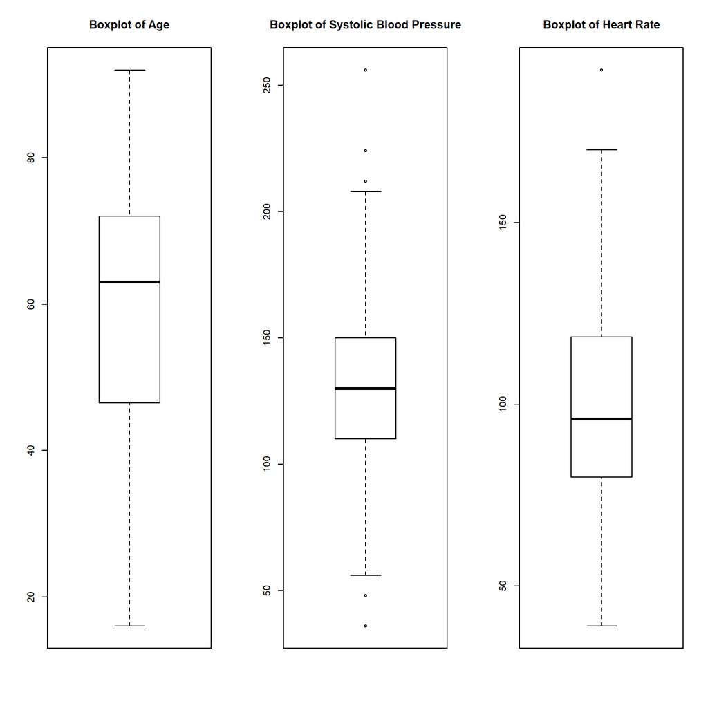

```r
> par(mfrow=c(1,3))
> boxplot(ICU$Age, main="Boxplot of Age")
> boxplot(ICU$Systolic, main="Boxplot of Systolic Blood Pressure")
> boxplot(ICU$HeartRate, main="Boxplot of Heart Rate")
```

As we can see above, the outliers are present in systolic blood pressure and heart rate. To see the values of the outliers, please see below, where the first row includes the outliers for systolic blood pressure, and the second includes outliers for heart rate.

```r
> systolic_outlier<-boxplot.stats(ICU$Systolic)
> heartrate_outlier<-boxplot.stats(ICU$HeartRate)
> systolic_outlier$out
```

```
[1]  48 212 224  36 256
```

```r
> heartrate_outlier$out
```

```
[1] 192
```

## 10.2 Crosstabs (relations between categorical variables)

```r
> sjt.xtab(ICU$Status, ICU$Sex, show.col.prc = TRUE)
```

| Status | Sex |  | Total |  |
| --- | --- | --- | --- | --- |
|  | Male | Female |  |  |
| Lived | 100 80.6 % | 60 78.9 % |  | 160 80 % |
| Died | 24 19.4 % | 16 21.1 % | 40 20 % |  |
| Total | 124 100 % | 76 100 % | 200 100 % |  |

```r
> sjt.xtab(ICU$Status, ICU$Race, show.col.prc = TRUE)
```

| Status | Race |  |  | Total |  |
| --- | --- | --- | --- | --- | --- |
|  | White | Black | Other |  |  |
| Lived | 138 78.9 % | 14 93.3 % | 8 80 % |  | 160 80 % |
| Died | 37 21.1 % | 1 6.7 % | 2 20 % | 40 20 % |  |
| Total | 175 100 % | 15 100 % | 10 100 % | 200 100 % |  |

```r
> sjt.xtab(ICU$Status, ICU$Service, show.col.prc = TRUE)
```

| Status | Service |  | Total |  |
| --- | --- | --- | --- | --- |
|  | Medical | Surgical |  |  |
| Lived | 67 72 % | 93 86.9 % |  | 160 80 % |
| Died | 26 28 % | 14 13.1 % | 40 20 % |  |
| Total | 93 100 % | 107 100 % | 200 100 % |  |

```r
> sjt.xtab(ICU$Status, ICU$Cancer, show.col.prc = TRUE)
```

| Status | Cancer |  | Total |  |
| --- | --- | --- | --- | --- |
|  | No | Yes |  |  |
| Lived | 144 80 % | 16 80 % |  | 160 80 % |
| Died | 36 20 % | 4 20 % | 40 20 % |  |
| Total | 180 100 % | 20 100 % | 200 100 % |  |

```r
> sjt.xtab(ICU$Status, ICU$Renal, show.col.prc = TRUE)
```

| Status | Renal |  | Total |  |
| --- | --- | --- | --- | --- |
|  | No | Yes |  |  |
| Lived | 149 82.3 % | 11 57.9 % |  | 160 80 % |
| Died | 32 17.7 % | 8 42.1 % | 40 20 % |  |
| Total | 181 100 % | 19 100 % | 200 100 % |  |

```r
> sjt.xtab(ICU$Status, ICU$Infection, show.col.prc = TRUE)
```

| Status | Infection |  | Total |  |
| --- | --- | --- | --- | --- |
|  | No | Yes |  |  |
| Lived | 100 86.2 % | 60 71.4 % |  | 160 80 % |
| Died | 16 13.8 % | 24 28.6 % | 40 20 % |  |
| Total | 116 100 % | 84 100 % | 200 100 % |  |

```r
> sjt.xtab(ICU$Status, ICU$CPR, show.col.prc = TRUE)
```

| Status | CPR |  | Total |  |
| --- | --- | --- | --- | --- |
|  | No | Yes |  |  |
| Lived | 154 82.4 % | 6 46.2 % |  | 160 80 % |
| Died | 33 17.6 % | 7 53.8 % | 40 20 % |  |
| Total | 187 100 % | 13 100 % | 200 100 % |  |

```r
> sjt.xtab(ICU$Status, ICU$Previous, show.col.prc = TRUE)
```

| Status | Previous |  | Total |  |
| --- | --- | --- | --- | --- |
|  | No | Yes |  |  |
| Lived | 137 80.6 % | 23 76.7 % |  | 160 80 % |
| Died | 33 19.4 % | 7 23.3 % | 40 20 % |  |
| Total | 170 100 % | 30 100 % | 200 100 % |  |

```r
> sjt.xtab(ICU$Status, ICU$Type, show.col.prc = TRUE)
```

| Status | Type |  | Total |  |
| --- | --- | --- | --- | --- |
|  | Elective | Emergency |  |  |
| Lived | 51 96.2 % | 109 74.1 % |  | 160 80 % |
| Died | 2 3.8 % | 38 25.9 % | 40 20 % |  |
| Total | 53 100 % | 147 100 % | 200 100 % |  |

```r
> sjt.xtab(ICU$Status, ICU$Fracture, show.col.prc = TRUE)
```

| Status | Fracture |  | Total |  |
| --- | --- | --- | --- | --- |
|  | No | Yes |  |  |
| Lived | 148 80 % | 12 80 % |  | 160 80 % |
| Died | 37 20 % | 3 20 % | 40 20 % |  |
| Total | 185 100 % | 15 100 % | 200 100 % |  |

```r
> sjt.xtab(ICU$Status, ICU$PO2, show.col.prc = TRUE)
```

| Status | PO2 |  | Total |  |
| --- | --- | --- | --- | --- |
|  | No | Yes |  |  |
| Lived | 149 81 % | 11 68.8 % |  | 160 80 % |
| Died | 35 19 % | 5 31.2 % | 40 20 % |  |
| Total | 184 100 % | 16 100 % | 200 100 % |  |

```r
> sjt.xtab(ICU$Status, ICU$PH, show.col.prc = TRUE)
```

| Status | PH |  | Total |  |
| --- | --- | --- | --- | --- |
|  | No | Yes |  |  |
| Lived | 151 80.7 % | 9 69.2 % |  | 160 80 % |
| Died | 36 19.3 % | 4 30.8 % | 40 20 % |  |
| Total | 187 100 % | 13 100 % | 200 100 % |  |

```r
> sjt.xtab(ICU$Status, ICU$PCO2, show.col.prc = TRUE)
```

| Status | PCO2 |  | Total |  |
| --- | --- | --- | --- | --- |
|  | No | Yes |  |  |
| Lived | 144 80 % | 16 80 % |  | 160 80 % |
| Died | 36 20 % | 4 20 % | 40 20 % |  |
| Total | 180 100 % | 20 100 % | 200 100 % |  |

```r
> sjt.xtab(ICU$Status, ICU$Bicarbonate, show.col.prc = TRUE)
```

| Status | Bicarbonate |  | Total |  |
| --- | --- | --- | --- | --- |
|  | No | Yes |  |  |
| Lived | 150 81.1 % | 10 66.7 % |  | 160 80 % |
| Died | 35 18.9 % | 5 33.3 % | 40 20 % |  |
| Total | 185 100 % | 15 100 % | 200 100 % |  |

```r
> sjt.xtab(ICU$Status, ICU$Creatinine, show.col.prc = TRUE)
```

| Status | Creatinine |  | Total |  |
| --- | --- | --- | --- | --- |
|  | No | Yes |  |  |
| Lived | 155 81.6 % | 5 50 % |  | 160 80 % |
| Died | 35 18.4 % | 5 50 % | 40 20 % |  |
| Total | 190 100 % | 10 100 % | 200 100 % |  |

```r
> sjt.xtab(ICU$Status, ICU$Consciousness, show.col.prc = TRUE)
```

| Status | Consciousness |  |  | Total |  |
| --- | --- | --- | --- | --- | --- |
|  | Conscious | Deep Stupor | Coma |  |  |
| Lived | 158 85.4 % | 0 0 % | 2 20 % |  | 160 80 % |
| Died | 27 14.6 % | 5 100 % | 8 80 % | 40 20 % |  |
| Total | 185 100 % | 5 100 % | 10 100 % | 200 100 % |  |

Statistically significant crosstabs include: Creatinine, Type, CPR, Infection,Renal, Service.

## 10.3 Logistic Regression

Prior to conducting a logistic regression, we would like to break down the systolic blood pressure into levels. We will use clinically defined levels for hypo, normal, elevated and hyper. Ranges below 90 are considered hypo, whereas ranges from 90 to 120 are considered normal, ranges between 120 and 129 are considered elevated, and 130 plus are considered hyper.

```r
> ICU$Systolic<-cut(ICU$Systolic, breaks=c(0,89,119,129,256))
> levels(ICU$Systolic)<-c("hypo", "normal", "elevated", "hyper")
```

```r
> ICU.m<-glm(formula=Status~Age+Sex+Race+Service+Cancer+Renal+Infection+CPR+Systolic+HeartRate+Previous+Type+Fracture+PO2+PH+PCO2+Bicarbonate+Creatinine+Consciousness, family=binomial(logit), data=ICU)
> summary(ICU.m)
```

```
Call:
glm(formula = Status ~ Age + Sex + Race + Service + Cancer +
    Renal + Infection + CPR + Systolic + HeartRate + Previous +
    Type + Fracture + PO2 + PH + PCO2 + Bicarbonate + Creatinine +
    Consciousness, family = binomial(logit), data = ICU)

Deviance Residuals:
     Min        1Q    Median        3Q       Max
-1.45809  -0.52365  -0.17347  -0.00019   2.92298

Coefficients:
                           Estimate Std. Error z value Pr(>|z|)
(Intercept)              -5.913e+00  2.250e+00  -2.627  0.00861 **
Age                       5.124e-02  1.829e-02   2.802  0.00508 **
SexFemale                -6.228e-01  5.563e-01  -1.119  0.26295
RaceBlack                -1.628e+01  1.320e+03  -0.012  0.99015
RaceOther                 4.335e-01  1.312e+00   0.330  0.74115
ServiceSurgical          -5.792e-01  6.411e-01  -0.904  0.36625
CancerYes                 3.157e+00  1.141e+00   2.766  0.00567 **
RenalYes                  1.605e-01  8.434e-01   0.190  0.84906
InfectionYes             -4.125e-02  5.657e-01  -0.073  0.94186
CPRYes                    1.347e+00  9.901e-01   1.360  0.17372
Systolicnormal           -2.175e+00  1.044e+00  -2.084  0.03713 *
Systolicelevated         -1.612e+00  1.114e+00  -1.447  0.14782
Systolichyper            -2.061e+00  1.026e+00  -2.008  0.04465 *
HeartRate                -9.748e-04  1.029e-02  -0.095  0.92455
PreviousYes               1.013e+00  6.937e-01   1.460  0.14439
TypeEmergency             3.396e+00  1.330e+00   2.553  0.01068 *
FractureYes               1.566e+00  1.101e+00   1.422  0.15506
PO2Yes                   -7.044e-01  9.923e-01  -0.710  0.47781
PHYes                     1.526e+00  1.229e+00   1.241  0.21463
PCO2Yes                  -2.447e+00  1.235e+00  -1.981  0.04756 *
BicarbonateYes           -8.800e-03  9.056e-01  -0.010  0.99225
CreatinineYes            -2.035e-01  1.139e+00  -0.179  0.85827
ConsciousnessDeep Stupor  3.538e+01  2.568e+03   0.014  0.98901
ConsciousnessComa         3.373e+00  1.359e+00   2.482  0.01307 *
---
Signif. codes:  0 '***' 0.001 '**' 0.01 '*' 0.05 '.' 0.1 ' ' 1

(Dispersion parameter for binomial family taken to be 1)

    Null deviance: 200.16  on 199  degrees of freedom
Residual deviance: 112.67  on 176  degrees of freedom
AIC: 160.67

Number of Fisher Scoring iterations: 17
```

```r
> confint(ICU.m)
```

```
                                 2.5 %      97.5 %
(Intercept)               -10.71446902 -1.69601255
Age                         0.01835185  0.09076391
SexFemale                  -1.76222223  0.44150426
RaceBlack                -406.17117888 48.28576524
RaceOther                  -2.78151725  2.76940774
ServiceSurgical            -1.87453755  0.66822713
CancerYes                   1.04815774  5.66235244
RenalYes                   -1.58805858  1.78878733
InfectionYes               -1.17641537  1.06336175
CPRYes                     -0.63018852  3.34518326
Systolicnormal             -4.37115591 -0.21283200
Systolicelevated           -3.96121708  0.47666682
Systolichyper              -4.25385307 -0.16344121
HeartRate                  -0.02182989  0.01893995
PreviousYes                -0.38940841  2.37091562
TypeEmergency               1.20038241  6.70600040
FractureYes                -0.77450551  3.72610086
PO2Yes                     -2.80364875  1.17162344
PHYes                      -0.83446254  4.05350727
PCO2Yes                    -5.12715251 -0.23880882
BicarbonateYes             -1.88096203  1.74562784
CreatinineYes              -2.55264347  1.98603281
ConsciousnessDeep Stupor -229.97748941          NA
ConsciousnessComa           0.93736975  6.35058207
```

```r
> exp(coef(ICU.m))
```

```
             (Intercept)                      Age                SexFemale
            2.704937e-03             1.052574e+00             5.364495e-01
               RaceBlack                RaceOther          ServiceSurgical
            8.463168e-08             1.542613e+00             5.603338e-01
               CancerYes                 RenalYes             InfectionYes
            2.350715e+01             1.174101e+00             9.595848e-01
                  CPRYes           Systolicnormal         Systolicelevated
            3.845560e+00             1.135578e-01             1.995610e-01
           Systolichyper                HeartRate              PreviousYes
            1.273357e-01             9.990257e-01             2.752703e+00
           TypeEmergency              FractureYes                   PO2Yes
            2.983051e+01             4.788341e+00             4.944214e-01
                   PHYes                  PCO2Yes           BicarbonateYes
            4.598443e+00             8.656750e-02             9.912381e-01
           CreatinineYes ConsciousnessDeep Stupor        ConsciousnessComa
            8.159074e-01             2.322342e+15             2.915368e+01
```

### 10.3.1 Final model

```r
> ICU.final.m<-glm(formula=Status~Age+Cancer+Systolic+PCO2+Consciousness+Type, family=binomial(logit),data=ICU)
> summary(ICU.final.m)
```

```
Call:
glm(formula = Status ~ Age + Cancer + Systolic + PCO2 + Consciousness +
    Type, family = binomial(logit), data = ICU)

Deviance Residuals:
    Min       1Q   Median       3Q      Max
-1.9242  -0.5616  -0.3078  -0.1039   2.5967

Coefficients:
                           Estimate Std. Error z value Pr(>|z|)
(Intercept)                -5.46992    1.78152  -3.070  0.00214 **
Age                         0.03715    0.01318   2.819  0.00481 **
CancerYes                   2.55498    1.06544   2.398  0.01648 *
Systolicnormal             -2.17702    0.87730  -2.481  0.01308 *
Systolicelevated           -1.71982    0.94888  -1.812  0.06991 .
Systolichyper              -2.02455    0.80102  -2.527  0.01149 *
PCO2Yes                    -1.46173    0.86529  -1.689  0.09116 .
ConsciousnessDeep Stupor   20.75726 1561.13214   0.013  0.98939
ConsciousnessComa           2.76952    0.97924   2.828  0.00468 **
TypeEmergency               3.65070    1.28917   2.832  0.00463 **
---
Signif. codes:  0 '***' 0.001 '**' 0.01 '*' 0.05 '.' 0.1 ' ' 1

(Dispersion parameter for binomial family taken to be 1)

    Null deviance: 200.16  on 199  degrees of freedom
Residual deviance: 125.60  on 190  degrees of freedom
AIC: 145.6

Number of Fisher Scoring iterations: 16
```

```r
> confint(ICU.final.m)
```

```
                                 2.5 %      97.5 %
(Intercept)                -9.46575467 -2.26757094
Age                         0.01291117  0.06506014
CancerYes                   0.59112234  4.95935713
Systolicnormal             -4.01598420 -0.51648433
Systolicelevated           -3.71304718  0.07016753
Systolichyper              -3.71337117 -0.50242069
PCO2Yes                    -3.36824530  0.08432436
ConsciousnessDeep Stupor -140.94294699          NA
ConsciousnessComa           0.99821470  4.98622776
TypeEmergency               1.60812369  6.92583339
```

```r
> exp(coef(ICU.final.m))
```

```
             (Intercept)                      Age                CancerYes
            4.211568e-03             1.037849e+00             1.287104e+01
          Systolicnormal         Systolicelevated            Systolichyper
            1.133791e-01             1.790977e-01             1.320539e-01
                 PCO2Yes ConsciousnessDeep Stupor        ConsciousnessComa
            2.318346e-01             1.034580e+09             1.595094e+01
           TypeEmergency
            3.850154e+01
```

```r
> pacman::p_load(rsample)
> set.seed(78)
> train_test_split <- initial_split(ICU)
> train <- training(train_test_split)
> test <- testing(train_test_split)
> (samp <- dim(train_test_split))
```

```
  analysis assessment          n          p
       150         50        200         24
```

```r
> ICU.tr<-glm(Status~Age+Cancer+Systolic+PCO2+Consciousness+Type, family=binomial(logit),data=train)
> summary(ICU.tr)
```

```
Call:
glm(formula = Status ~ Age + Cancer + Systolic + PCO2 + Consciousness +
    Type, family = binomial(logit), data = train)

Deviance Residuals:
     Min        1Q    Median        3Q       Max
-1.67290  -0.48913  -0.19920  -0.00002   2.22166

Coefficients:
                           Estimate Std. Error z value Pr(>|z|)
(Intercept)               -21.10717 2282.51458  -0.009  0.99262
Age                         0.01866    0.01534   1.217  0.22364
CancerYes                   4.24030    1.76849   2.398  0.01650 *
Systolicnormal             -3.07973    1.10903  -2.777  0.00549 **
Systolicelevated           -4.27230    1.83340  -2.330  0.01979 *
Systolichyper              -2.54336    0.99130  -2.566  0.01030 *
PCO2Yes                    -2.54676    1.41142  -1.804  0.07117 .
ConsciousnessDeep Stupor   40.78134 6527.94176   0.006  0.99502
ConsciousnessComa           4.33342    1.78235   2.431  0.01504 *
TypeEmergency              20.91660 2282.51417   0.009  0.99269
---
Signif. codes:  0 '***' 0.001 '**' 0.01 '*' 0.05 '.' 0.1 ' ' 1

(Dispersion parameter for binomial family taken to be 1)

    Null deviance: 144.406  on 149  degrees of freedom
Residual deviance:  72.666  on 140  degrees of freedom
AIC: 92.666

Number of Fisher Scoring iterations: 19
```

### 10.3.2 Testing & training the model

```r
> predicted.val<-predict(ICU.tr, newdata=test)
> head(predicted.val)
```

```
         2          7          8         11         15         17
 -2.169124 -23.011067  -2.174011 -22.624007  -1.502103 -22.624007
```

```r
> predicted.prob <- predict(ICU.tr, test, type = "response")
> head( predict( ICU.tr, test, type="response") )
```

```
           2            7            8           11           15
1.025576e-01 1.014894e-10 1.021087e-01 1.494578e-10 1.821121e-01
          17
1.494578e-10
```

```r
> predicted.classes <- ifelse( predicted.prob > 0.5, "Lived", "Dead" )
> head(predicted.classes)
```

```
     2      7      8     11     15     17
"Dead" "Dead" "Dead" "Dead" "Dead" "Dead"
```

```r
> pacman::p_load(car)
> car::vif(ICU.tr)
```

```
                  GVIF Df GVIF^(1/(2*Df))
Age           1.073842  1        1.036264
Cancer        1.527300  1        1.235840
Systolic      1.419763  3        1.060155
PCO2          1.980314  1        1.407236
Consciousness 1.931509  2        1.178892
Type          1.139286  1        1.067374
```

```r
> fit0<-glm(Status~1, family=binomial(logit), data=train)
> summary(fit0)
```

```
Call:
glm(formula = Status ~ 1, family = binomial(logit), data = train)

Deviance Residuals:
    Min       1Q   Median       3Q      Max
-0.6428  -0.6428  -0.6428  -0.6428   1.8322

Coefficients:
            Estimate Std. Error z value Pr(>|z|)
(Intercept)  -1.4718     0.2095  -7.024 2.16e-12 ***
---
Signif. codes:  0 '***' 0.001 '**' 0.01 '*' 0.05 '.' 0.1 ' ' 1

(Dispersion parameter for binomial family taken to be 1)

    Null deviance: 144.41  on 149  degrees of freedom
Residual deviance: 144.41  on 149  degrees of freedom
AIC: 146.41

Number of Fisher Scoring iterations: 4
```

```r
> fitall<-glm(Status~Age+Cancer+Systolic+PCO2+Consciousness+Type, family=binomial(logit), data=train)
> summary(fitall)
```

```
Call:
glm(formula = Status ~ Age + Cancer + Systolic + PCO2 + Consciousness +
    Type, family = binomial(logit), data = train)

Deviance Residuals:
     Min        1Q    Median        3Q       Max
-1.67290  -0.48913  -0.19920  -0.00002   2.22166

Coefficients:
                           Estimate Std. Error z value Pr(>|z|)
(Intercept)               -21.10717 2282.51458  -0.009  0.99262
Age                         0.01866    0.01534   1.217  0.22364
CancerYes                   4.24030    1.76849   2.398  0.01650 *
Systolicnormal             -3.07973    1.10903  -2.777  0.00549 **
Systolicelevated           -4.27230    1.83340  -2.330  0.01979 *
Systolichyper              -2.54336    0.99130  -2.566  0.01030 *
PCO2Yes                    -2.54676    1.41142  -1.804  0.07117 .
ConsciousnessDeep Stupor   40.78134 6527.94176   0.006  0.99502
ConsciousnessComa           4.33342    1.78235   2.431  0.01504 *
TypeEmergency              20.91660 2282.51417   0.009  0.99269
---
Signif. codes:  0 '***' 0.001 '**' 0.01 '*' 0.05 '.' 0.1 ' ' 1

(Dispersion parameter for binomial family taken to be 1)

    Null deviance: 144.406  on 149  degrees of freedom
Residual deviance:  72.666  on 140  degrees of freedom
AIC: 92.666

Number of Fisher Scoring iterations: 19
```

```r
> anova(fitall, fit0, test="Chisq")
```

```
Analysis of Deviance Table

Model 1: Status ~ Age + Cancer + Systolic + PCO2 + Consciousness + Type
Model 2: Status ~ 1
  Resid. Df Resid. Dev Df Deviance  Pr(>Chi)
1       140     72.666
2       149    144.406 -9   -71.74 6.934e-12 ***
---
Signif. codes:  0 '***' 0.001 '**' 0.01 '*' 0.05 '.' 0.1 ' ' 1
```

```r
> pacman::p_load(survey)
> regTermTest(ICU.tr, "Age")
```

```
Wald test for Age
 in glm(formula = Status ~ Age + Cancer + Systolic + PCO2 + Consciousness +
    Type, family = binomial(logit), data = train)
F =  1.480864  on  1  and  140  df: p= 0.22569
```

```r
> regTermTest(ICU.tr, "Cancer")
```

```
Wald test for Cancer
 in glm(formula = Status ~ Age + Cancer + Systolic + PCO2 + Consciousness +
    Type, family = binomial(logit), data = train)
F =  5.748968  on  1  and  140  df: p= 0.017817
```

```r
> regTermTest(ICU.tr, "Systolic")
```

```
Wald test for Systolic
 in glm(formula = Status ~ Age + Cancer + Systolic + PCO2 + Consciousness +
    Type, family = binomial(logit), data = train)
F =  3.105522  on  3  and  140  df: p= 0.028612
```

```r
> regTermTest(ICU.tr, "Type")
```

```
Wald test for Type
 in glm(formula = Status ~ Age + Cancer + Systolic + PCO2 + Consciousness +
    Type, family = binomial(logit), data = train)
F =  8.3976e-05  on  1  and  140  df: p= 0.9927
```

```r
> regTermTest(ICU.tr, "PCO2")
```

```
Wald test for PCO2
 in glm(formula = Status ~ Age + Cancer + Systolic + PCO2 + Consciousness +
    Type, family = binomial(logit), data = train)
F =  3.255852  on  1  and  140  df: p= 0.073319
```

```r
> regTermTest(ICU.tr, "Consciousness")
```

```
Wald test for Consciousness
 in glm(formula = Status ~ Age + Cancer + Systolic + PCO2 + Consciousness +
    Type, family = binomial(logit), data = train)
F =  2.955636  on  2  and  140  df: p= 0.055302
```

## 10.4 Classification and Regression Trees

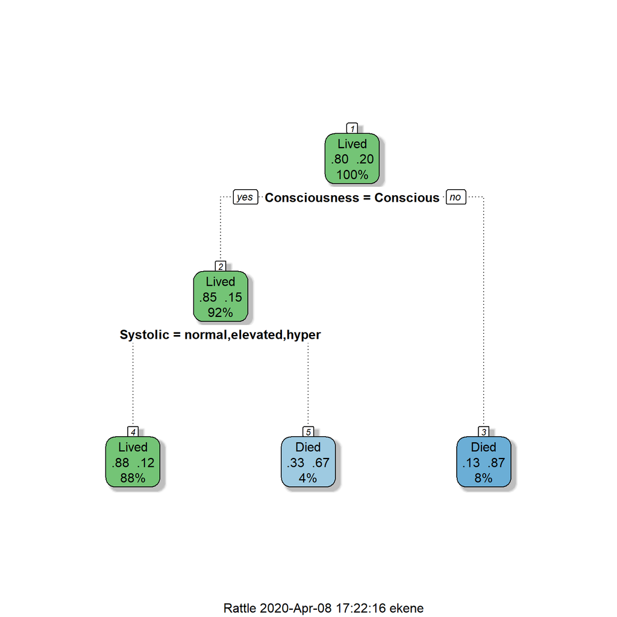

```r
> pacman::p_load(rpart, rpart.plot, rattle, dplyr)
> set.seed(2715)
>
> #final model
> icutree=rpart(Status~Age+Cancer+Systolic+Type+PCO2+Consciousness+Type+Fracture+Sex+Race+Service+Renal+Infection+CPR+HeartRate+Previous+PO2+PH+Bicarbonate+Creatinine+Consciousness, method="class", data=ICU)
> #rpart.plot(icutree,
>            #extra = 104, # show fitted class, probs, percentages
>            #box.palette = "GnYlRd", # color scheme
>            #prefix = "Status\n",
>            #branch.lty = 1, # solid branch lines, 3 = dotted
>            #shadow.col = "gray", # shadows under the node boxes
>            #split.prefix = "is ", # put "is " before split text
>            #split.suffix = "?", # put "?" after split text
>            #nn = TRUE, # display the node numbers
>            #tweak = 1.2)
> fancyRpartPlot(icutree)
```

```r
> printcp(icutree)
```

```
Classification tree:
rpart(formula = Status ~ Age + Cancer + Systolic + Type + PCO2 +
    Consciousness + Type + Fracture + Sex + Race + Service +
    Renal + Infection + CPR + HeartRate + Previous + PO2 + PH +
    Bicarbonate + Creatinine + Consciousness, data = ICU, method = "class")

Variables actually used in tree construction:
[1] Consciousness Systolic

Root node error: 40/200 = 0.2

n= 200

     CP nsplit rel error xerror    xstd
1 0.275      0     1.000  1.000 0.14142
2 0.075      1     0.725  0.725 0.12449
3 0.010      2     0.650  0.725 0.12449
```

```r
> predicted.classes <- icutree %>% predict(, data=icu, type = "class")
> head(predicted.classes, 12)
```

```
    1     2     3     4     5     6     7     8     9    10    11    12
Lived Lived Lived Lived Lived Lived Lived Lived Lived Lived Lived Lived
Levels: Lived Died
```

```r
> mean(predicted.classes == ICU$Status)
```

```
[1] 0.87
```

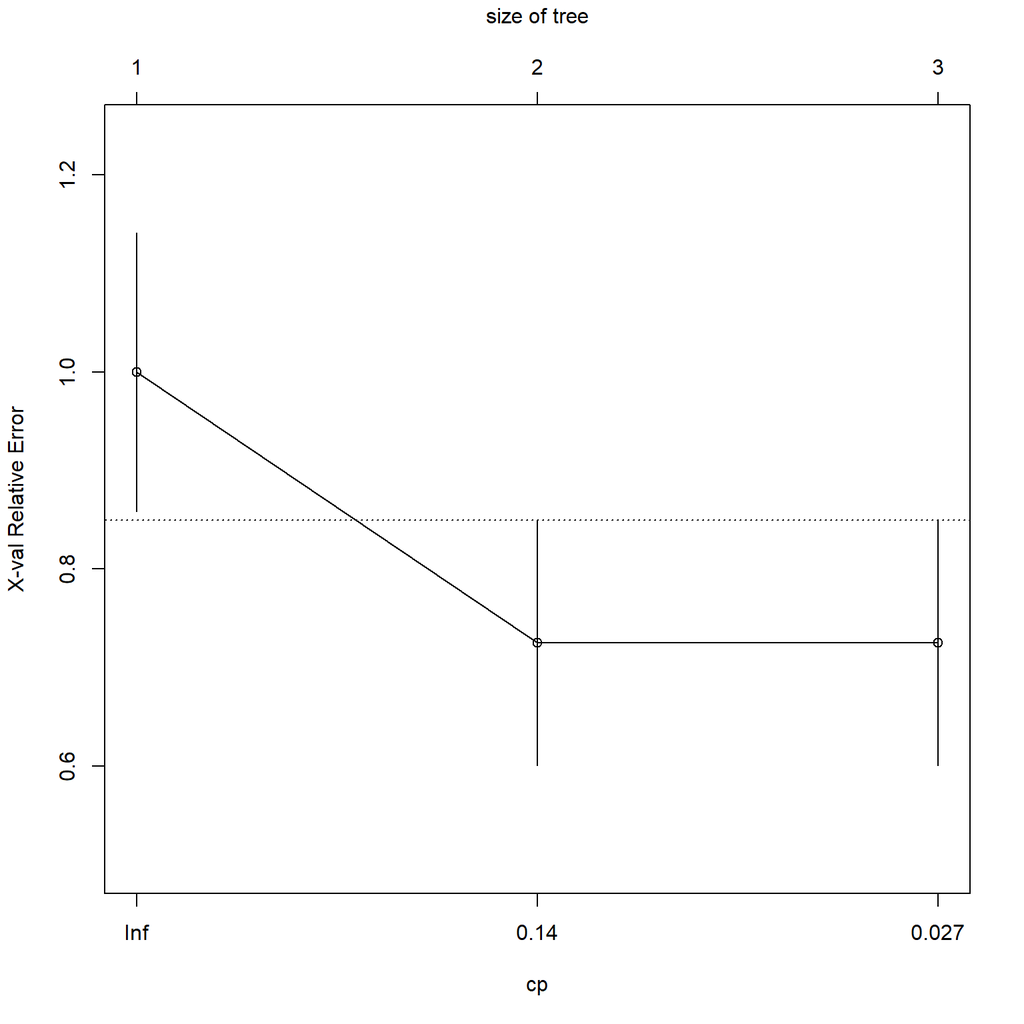

```r
> plotcp(icutree)
```

A work by Ekene Olatunji, Caterine Nassralla, Victoria Chin, Bassam Chamas, and Sajiya Somji

*Msc. eHealth*

*DeGroote School of Business*

*eHealth 705 Statistics for eHealth - Final Project*